# Randomization + Simulation

## Overview

In this lab we practice how randomize a factorial design. We will simulate an example to show the importance of randomization.

```r
## Load relevant libraries
library(tidyverse)
#library(sf)
#library(spsurvey)
```

## Experiment Example:

Question: How does competition impact feeding rate of red rock crab?

- Treatment 1: 3 levels of crab density (1 ind, 5 ind, 10 ind).
- Treatment 2: 2 Types of food: (Squid, Mussel)
- Response Variable: Difference in weight of food input before and after 2 hours.
- Design Type: $3\times 2!$ design.
- Replicate 10 times.
- For efficiency, we will block through time in case any variables change.

```r
## Define the factorial design.
food <- c("Squid", "Mussel")
density <- c(1, 5, 10)
design <- expand.grid(food = food, density = density, block = 1:10)
```

## Simulation for the results

- Let’s assume that the random noise is Normally distributed with standard deviation $\sigma = 0.8$.

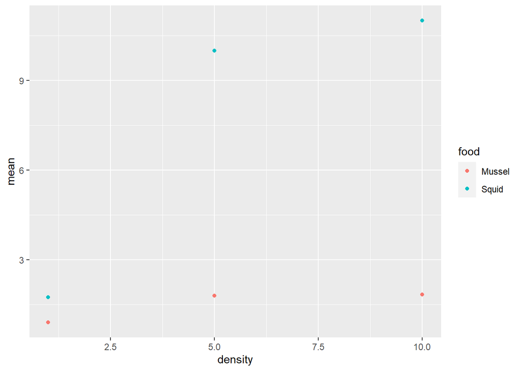

```r
  params <- data.frame(food = rep(food, each = 3), density = rep(density, 2), mean = c(1.75, 10, 11, 0.9, 1.8, 1.83))
ggplot(data = params, aes(x = density, y = mean, colour = food)) + geom_point()
```

## Randomize the order for each block.

```r
design.block.rand <- design %>%
    group_by(block) %>%
    mutate(sampleOrder = sample(n())) %>%
    arrange(sampleOrder, .by_group = TRUE) %>%
    ungroup()
```

## Simulate Some Data

```r
data.rand <- design.block.rand %>%
  group_by(block) %>%
  mutate(block.effect = rnorm(1, 0, 0.2)) %>%
  ungroup() %>%
  left_join(params) %>%
  mutate(response = rnorm(n(), mean + block.effect, 0.8)) %>%
  mutate(density = factor(density))
```

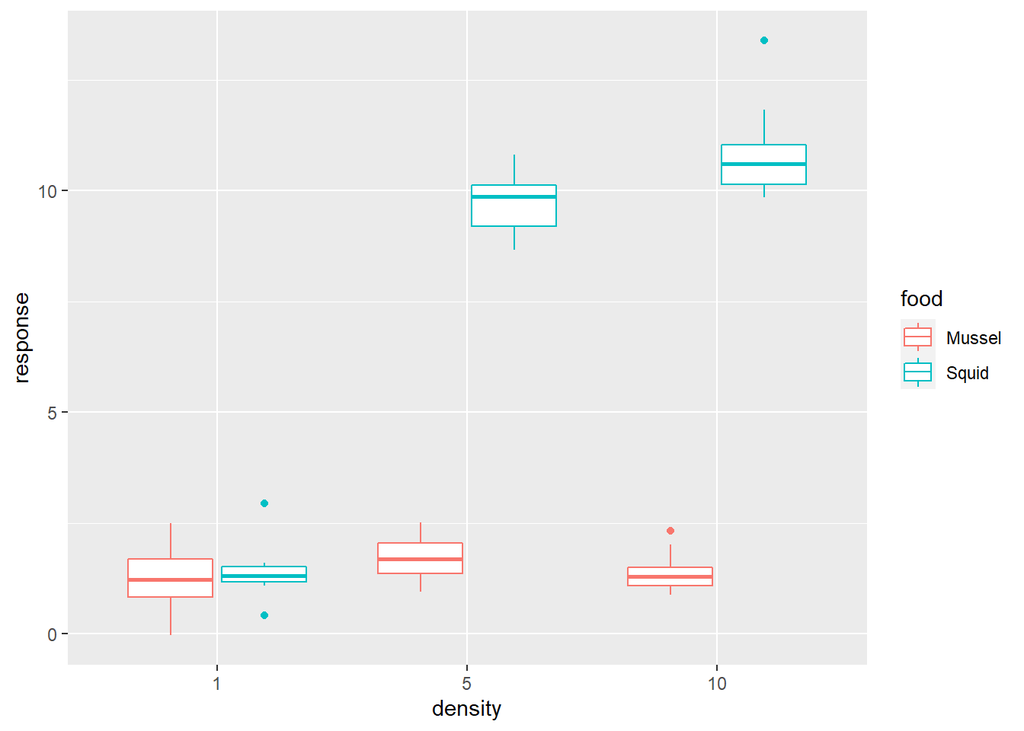

```r
ggplot(data = data.rand, aes(x = density, y = response, colour = food)) + geom_boxplot()
```

## Why is the factorial design so important?

Let’s first look at this data by estimating the means in each treatment only. In other words, let’s run this experiment ignoring interactions and see what the impact of squid is.

```r
  mod.add <- aov(response ~ food + density, data = data.rand)
  coef(mod.add)
```

```
## (Intercept)   foodSquid    density5   density10
##   -1.609907    5.874429    4.411609    4.794938
```

## Now let’s analyse the data properly.

```r
  mod.int <- aov(response ~ food*density, data = data.rand)
  coef(mod.int)
```

```
##         (Intercept)           foodSquid            density5           density10
##           1.2512716           0.1520725           0.4780919           0.1449198
##  foodSquid:density5 foodSquid:density10
##           7.8670346           9.3000363
```

## Randomize your own experiment